# Kira Plastinina Customer Analysis

Joshua Kibuye

2022-03-26

# 1. Problem Definition

Kira Plastinina is a Russian brand that is sold through a defunct chain of retail stores in Russia, Ukraine, Kazakhstan, Belarus, China, Philippines, and Armenia. The brand’s Sales and Marketing team would like to understand their customer’s behavior from data that they have collected over the past year. More specifically, they would like to learn the characteristics of customer groups.

# 2. Data Sourcing

```r
#Loading the dataset
df <- read.csv('http://bit.ly/EcommerceCustomersDataset')
```

# 3. Check the Dataset

```r
#Previewing the top of the dataset
head(df)
```

|  | Administrative | Administrative_Duration | Informational | Informational_Duration | ProductRelated | ProductRelated_Duration | BounceRates | ExitRates | PageValues | SpecialDay | Month | OperatingSystems | Browser | Region | TrafficType | VisitorType | Weekend | Revenue |
| --- | --- | --- | --- | --- | --- | --- | --- | --- | --- | --- | --- | --- | --- | --- | --- | --- | --- | --- |
| 1 | 0 | 0 | 0 | 0 | 1 | 0.000000 | 0.20000000 | 0.2000000 | 0 | 0 | Feb | 1 | 1 | 1 | 1 | Returning_Visitor | FALSE | FALSE |
| 2 | 0 | 0 | 0 | 0 | 2 | 64.000000 | 0.00000000 | 0.1000000 | 0 | 0 | Feb | 2 | 2 | 1 | 2 | Returning_Visitor | FALSE | FALSE |
| 3 | 0 | -1 | 0 | -1 | 1 | -1.000000 | 0.20000000 | 0.2000000 | 0 | 0 | Feb | 4 | 1 | 9 | 3 | Returning_Visitor | FALSE | FALSE |
| 4 | 0 | 0 | 0 | 0 | 2 | 2.666667 | 0.05000000 | 0.1400000 | 0 | 0 | Feb | 3 | 2 | 2 | 4 | Returning_Visitor | FALSE | FALSE |
| 5 | 0 | 0 | 0 | 0 | 10 | 627.500000 | 0.02000000 | 0.0500000 | 0 | 0 | Feb | 3 | 3 | 1 | 4 | Returning_Visitor | TRUE | FALSE |
| 6 | 0 | 0 | 0 | 0 | 19 | 154.216667 | 0.01578947 | 0.0245614 | 0 | 0 | Feb | 2 | 2 | 1 | 3 | Returning_Visitor | FALSE | FALSE |

```r
#Checking the bottom of the dataset
tail(df)
```

|  | Administrative | Administrative_Duration | Informational | Informational_Duration | ProductRelated | ProductRelated_Duration | BounceRates | ExitRates | PageValues | SpecialDay | Month | OperatingSystems | Browser | Region | TrafficType | VisitorType | Weekend | Revenue |
| --- | --- | --- | --- | --- | --- | --- | --- | --- | --- | --- | --- | --- | --- | --- | --- | --- | --- | --- |
| 12325 | 0 | 0 | 1 | 0 | 16 | 503.000 | 0.000000000 | 0.03764706 | 0.00000 | 0 | Nov | 2 | 2 | 1 | 1 | Returning_Visitor | FALSE | FALSE |
| 12326 | 3 | 145 | 0 | 0 | 53 | 1783.792 | 0.007142857 | 0.02903061 | 12.24172 | 0 | Dec | 4 | 6 | 1 | 1 | Returning_Visitor | TRUE | FALSE |
| 12327 | 0 | 0 | 0 | 0 | 5 | 465.750 | 0.000000000 | 0.02133333 | 0.00000 | 0 | Nov | 3 | 2 | 1 | 8 | Returning_Visitor | TRUE | FALSE |
| 12328 | 0 | 0 | 0 | 0 | 6 | 184.250 | 0.083333333 | 0.08666667 | 0.00000 | 0 | Nov | 3 | 2 | 1 | 13 | Returning_Visitor | TRUE | FALSE |
| 12329 | 4 | 75 | 0 | 0 | 15 | 346.000 | 0.000000000 | 0.02105263 | 0.00000 | 0 | Nov | 2 | 2 | 3 | 11 | Returning_Visitor | FALSE | FALSE |
| 12330 | 0 | 0 | 0 | 0 | 3 | 21.250 | 0.000000000 | 0.06666667 | 0.00000 | 0 | Nov | 3 | 2 | 1 | 2 | New_Visitor | TRUE | FALSE |

```r
#Looking at the shape of the dataset
dim(df)
```

```
## [1] 12330    18
```

The dataset has 12330 records and 18 colums

```r
#Looking at the datatypes of the dataset
sapply(df, class)
```

```
##          Administrative Administrative_Duration           Informational
##               "integer"               "numeric"               "integer"
##  Informational_Duration          ProductRelated ProductRelated_Duration
##               "numeric"               "integer"               "numeric"
##             BounceRates               ExitRates              PageValues
##               "numeric"               "numeric"               "numeric"
##              SpecialDay                   Month        OperatingSystems
##               "numeric"             "character"               "integer"
##                 Browser                  Region             TrafficType
##               "integer"               "integer"               "integer"
##             VisitorType                 Weekend                 Revenue
##             "character"               "logical"               "logical"
```

Some of the datatypes will need encoding.

```r
#Getting more detailed look of the dataset
library(dplyr)
glimpse(df)
```

```
## Rows: 12,330
## Columns: 18
## $ Administrative          <int> 0, 0, 0, 0, 0, 0, 0, 1, 0, 0, 0, 0, 0, 0, 0, 2~
## $ Administrative_Duration <dbl> 0, 0, -1, 0, 0, 0, -1, -1, 0, 0, 0, 0, 0, 0, 0~
## $ Informational           <int> 0, 0, 0, 0, 0, 0, 0, 0, 0, 0, 0, 0, 0, 0, 0, 0~
## $ Informational_Duration  <dbl> 0, 0, -1, 0, 0, 0, -1, -1, 0, 0, 0, 0, 0, 0, 0~
## $ ProductRelated          <int> 1, 2, 1, 2, 10, 19, 1, 1, 2, 3, 3, 16, 7, 6, 2~
## $ ProductRelated_Duration <dbl> 0.000000, 64.000000, -1.000000, 2.666667, 627.~
## $ BounceRates             <dbl> 0.200000000, 0.000000000, 0.200000000, 0.05000~
## $ ExitRates               <dbl> 0.200000000, 0.100000000, 0.200000000, 0.14000~
## $ PageValues              <dbl> 0, 0, 0, 0, 0, 0, 0, 0, 0, 0, 0, 0, 0, 0, 0, 0~
## $ SpecialDay              <dbl> 0.0, 0.0, 0.0, 0.0, 0.0, 0.0, 0.4, 0.0, 0.8, 0~
## $ Month                   <chr> "Feb", "Feb", "Feb", "Feb", "Feb", "Feb", "Feb~
## $ OperatingSystems        <int> 1, 2, 4, 3, 3, 2, 2, 1, 2, 2, 1, 1, 1, 2, 3, 1~
## $ Browser                 <int> 1, 2, 1, 2, 3, 2, 4, 2, 2, 4, 1, 1, 1, 5, 2, 1~
## $ Region                  <int> 1, 1, 9, 2, 1, 1, 3, 1, 2, 1, 3, 4, 1, 1, 3, 9~
## $ TrafficType             <int> 1, 2, 3, 4, 4, 3, 3, 5, 3, 2, 3, 3, 3, 3, 3, 3~
## $ VisitorType             <chr> "Returning_Visitor", "Returning_Visitor", "Ret~
## $ Weekend                 <lgl> FALSE, FALSE, FALSE, FALSE, TRUE, FALSE, FALSE~
## $ Revenue                 <lgl> FALSE, FALSE, FALSE, FALSE, FALSE, FALSE, FALS~
```

```r
#Statistical summary of the dataset
summary(df)
```

```
##  Administrative   Administrative_Duration Informational
##  Min.   : 0.000   Min.   :  -1.00         Min.   : 0.000
##  1st Qu.: 0.000   1st Qu.:   0.00         1st Qu.: 0.000
##  Median : 1.000   Median :   8.00         Median : 0.000
##  Mean   : 2.318   Mean   :  80.91         Mean   : 0.504
##  3rd Qu.: 4.000   3rd Qu.:  93.50         3rd Qu.: 0.000
##  Max.   :27.000   Max.   :3398.75         Max.   :24.000
##  NA's   :14       NA's   :14              NA's   :14
##  Informational_Duration ProductRelated   ProductRelated_Duration
##  Min.   :  -1.00        Min.   :  0.00   Min.   :   -1.0
##  1st Qu.:   0.00        1st Qu.:  7.00   1st Qu.:  185.0
##  Median :   0.00        Median : 18.00   Median :  599.8
##  Mean   :  34.51        Mean   : 31.76   Mean   : 1196.0
##  3rd Qu.:   0.00        3rd Qu.: 38.00   3rd Qu.: 1466.5
##  Max.   :2549.38        Max.   :705.00   Max.   :63973.5
##  NA's   :14             NA's   :14       NA's   :14
##   BounceRates         ExitRates         PageValues        SpecialDay
##  Min.   :0.000000   Min.   :0.00000   Min.   :  0.000   Min.   :0.00000
##  1st Qu.:0.000000   1st Qu.:0.01429   1st Qu.:  0.000   1st Qu.:0.00000
##  Median :0.003119   Median :0.02512   Median :  0.000   Median :0.00000
##  Mean   :0.022152   Mean   :0.04300   Mean   :  5.889   Mean   :0.06143
##  3rd Qu.:0.016684   3rd Qu.:0.05000   3rd Qu.:  0.000   3rd Qu.:0.00000
##  Max.   :0.200000   Max.   :0.20000   Max.   :361.764   Max.   :1.00000
##  NA's   :14         NA's   :14
##     Month           OperatingSystems    Browser           Region
##  Length:12330       Min.   :1.000    Min.   : 1.000   Min.   :1.000
##  Class :character   1st Qu.:2.000    1st Qu.: 2.000   1st Qu.:1.000
##  Mode  :character   Median :2.000    Median : 2.000   Median :3.000
##                     Mean   :2.124    Mean   : 2.357   Mean   :3.147
##                     3rd Qu.:3.000    3rd Qu.: 2.000   3rd Qu.:4.000
##                     Max.   :8.000    Max.   :13.000   Max.   :9.000
##
##   TrafficType    VisitorType         Weekend         Revenue
##  Min.   : 1.00   Length:12330       Mode :logical   Mode :logical
##  1st Qu.: 2.00   Class :character   FALSE:9462      FALSE:10422
##  Median : 2.00   Mode  :character   TRUE :2868      TRUE :1908
##  Mean   : 4.07
##  3rd Qu.: 4.00
##  Max.   :20.00
##
```

```r
#Viewing the dataset
View(df)
```

# 4. Perform Data Cleaning

```r
#Changing the column names to lower case for uniformity
names(df) <- tolower(names(df))
```

```r
#Checking for null values
colSums(is.na(df))
```

```
##          administrative administrative_duration           informational
##                      14                      14                      14
##  informational_duration          productrelated productrelated_duration
##                      14                      14                      14
##             bouncerates               exitrates              pagevalues
##                      14                      14                       0
##              specialday                   month        operatingsystems
##                       0                       0                       0
##                 browser                  region             traffictype
##                       0                       0                       0
##             visitortype                 weekend                 revenue
##                       0                       0                       0
```

There are 14 null values in the some columns of the dataset.

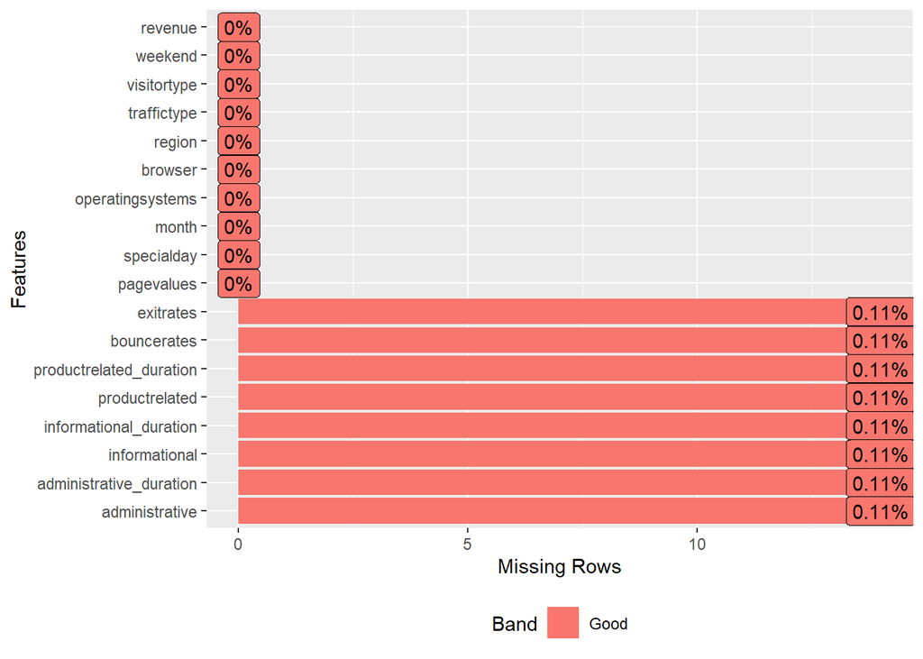

```r
#Plotting the percantage of missing to know how we will deal with them
library(DataExplorer)
plot_missing(df)
```

The missing data is only a small percantage, we therefore drop them.

```r
#Dropping missing values
df <- na.omit(df)
```

```r
#Checking if the changes have taken effect
sum(colSums(is.na(df)))
```

```
## [1] 0
```

All null values have been dropped.

```r
#Checking for duplicate values
sum(duplicated(df))
```

```
## [1] 117
```

There are 117 duplicate values. We will drop them.

```r
df <- df[!duplicated(df),]
dim(df)
```

```
## [1] 12199    18
```

We drop the duplicates and attain a number of 12199 records.

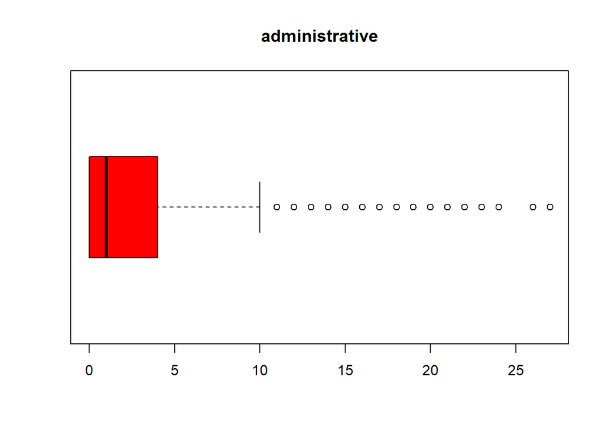

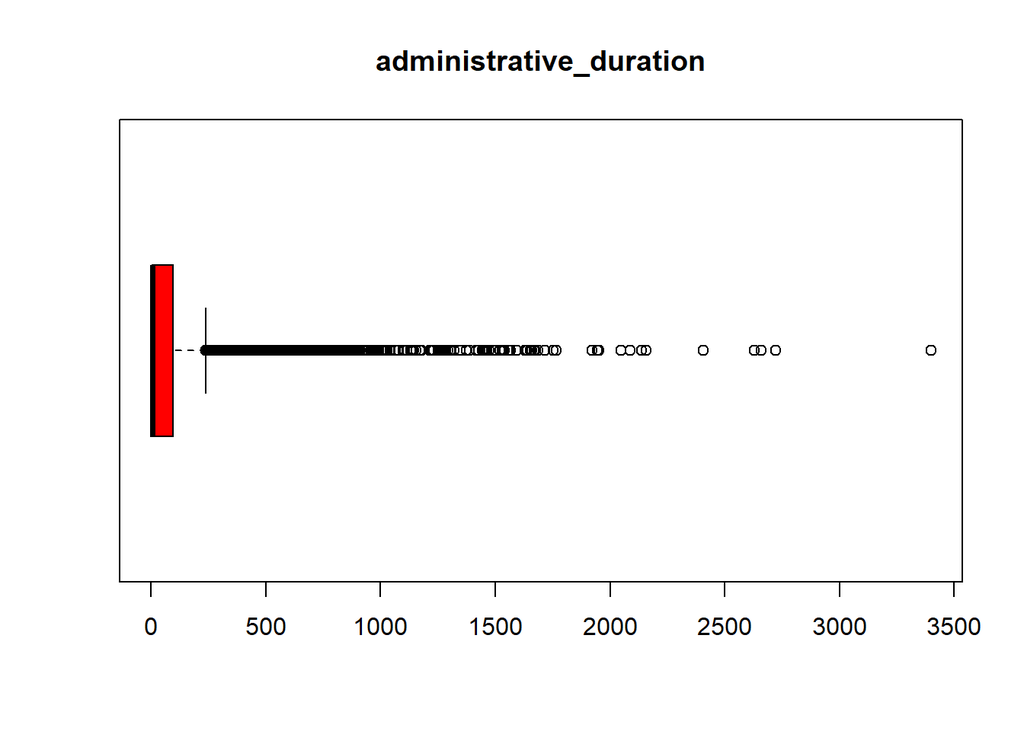

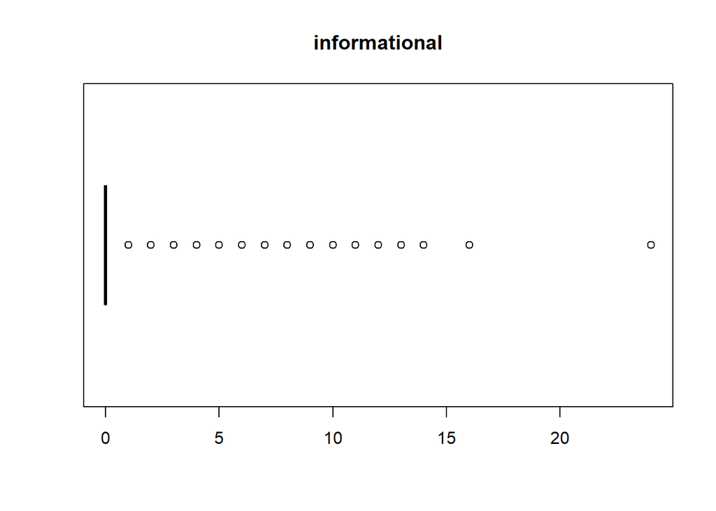

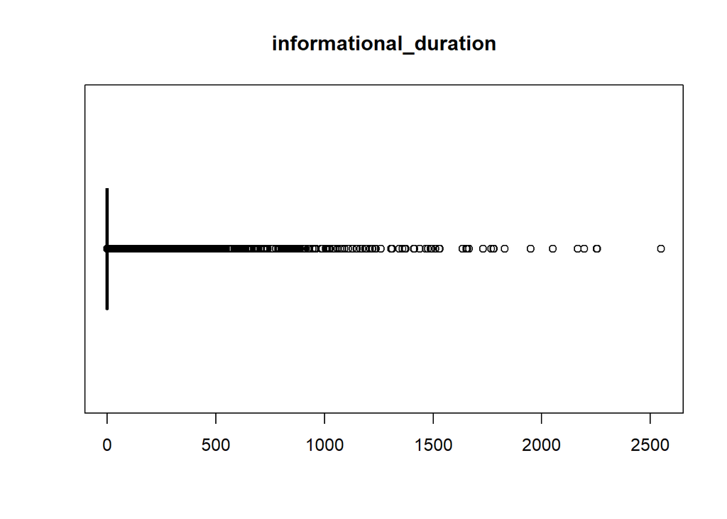

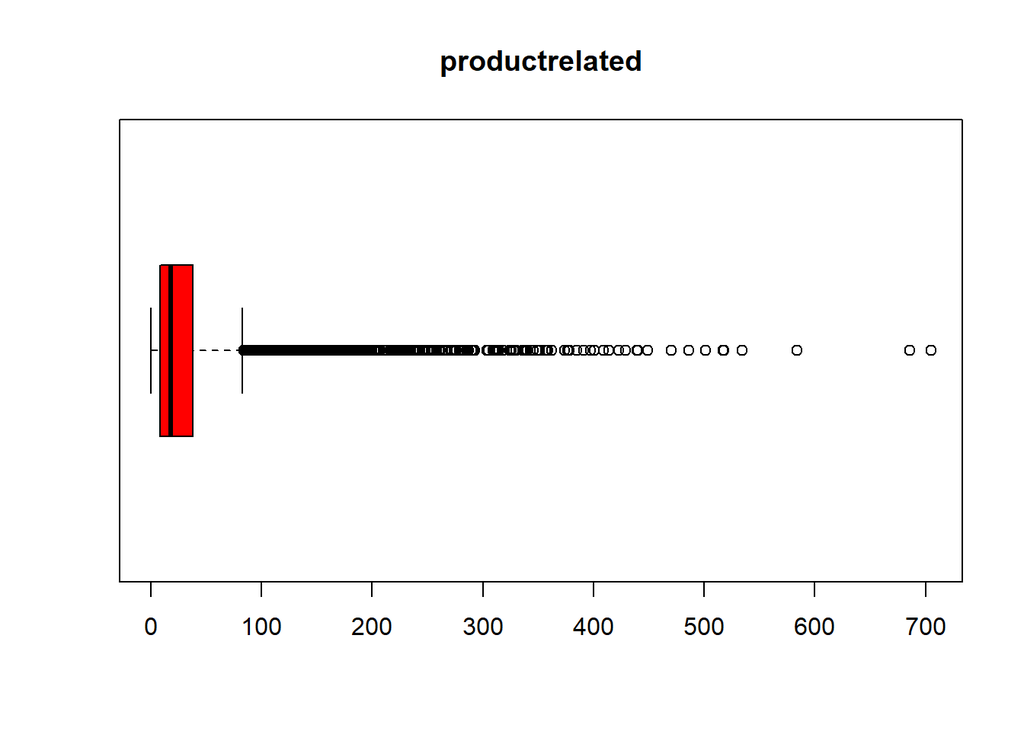

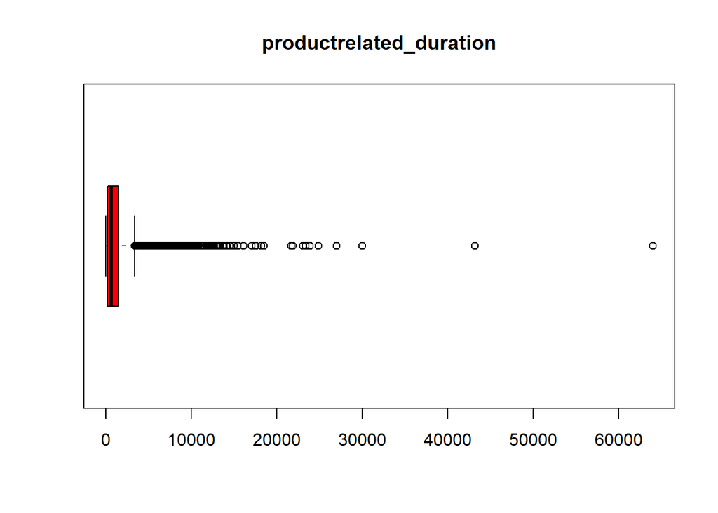

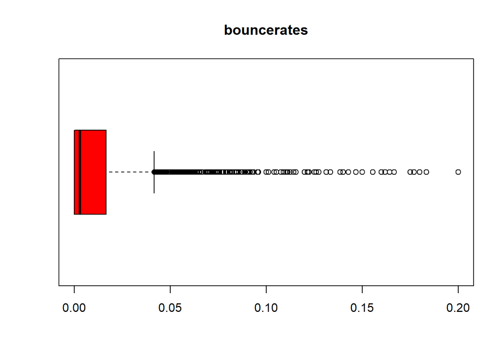

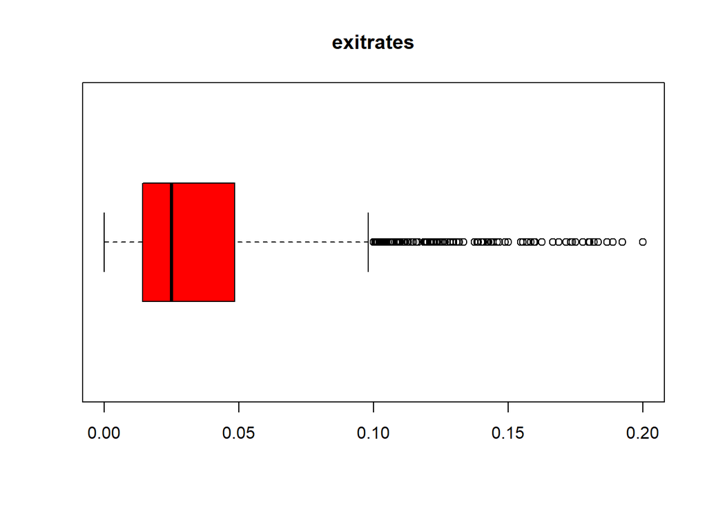

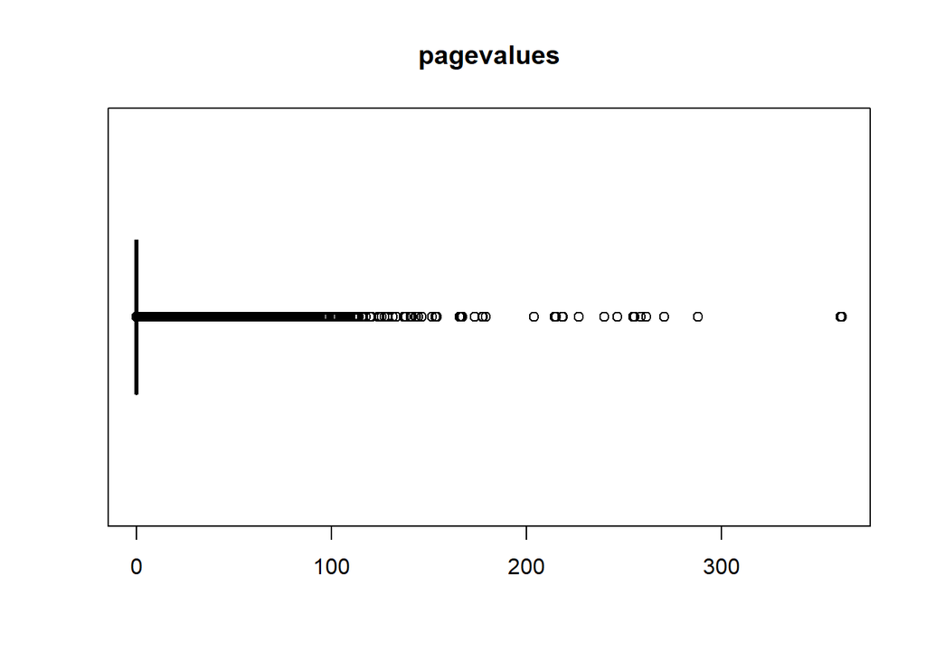

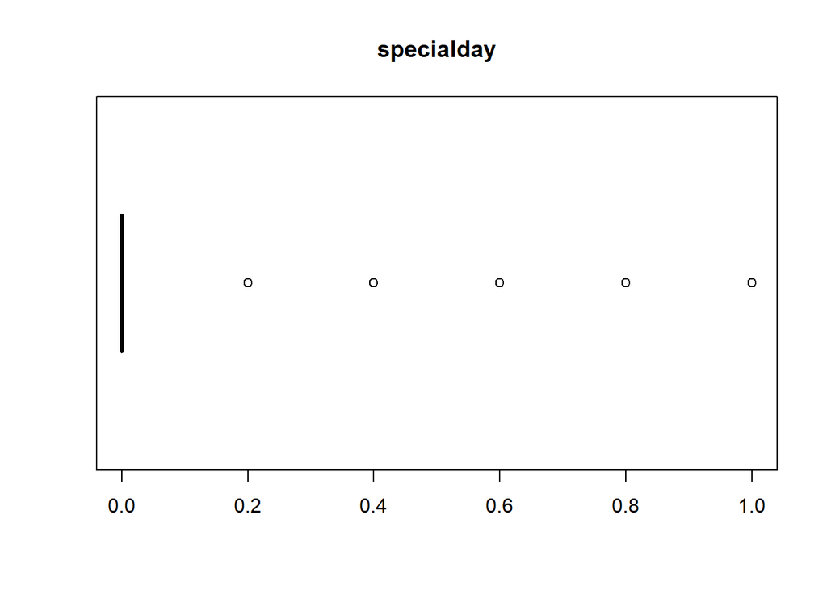

```r
for(i in 1:10) {
    boxplot(df[,i], main=names(df)[i], col = "red", horizontal=TRUE)}
```

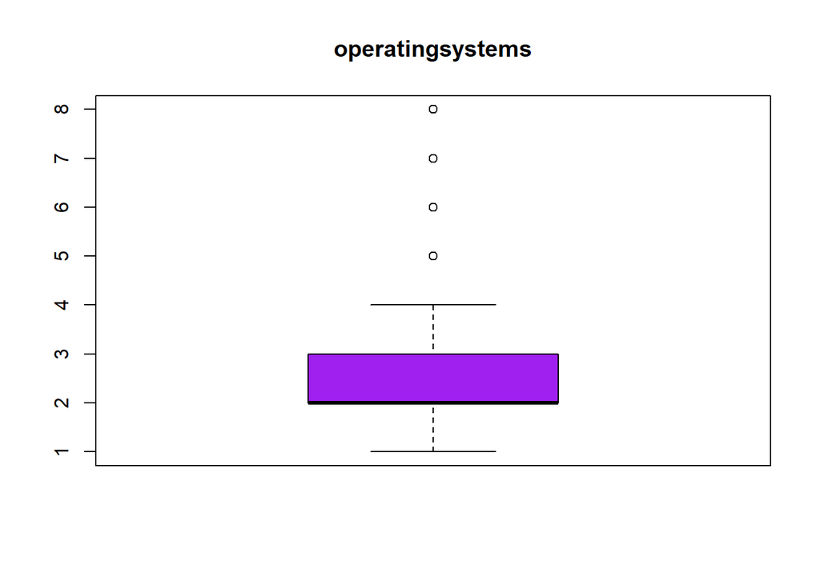

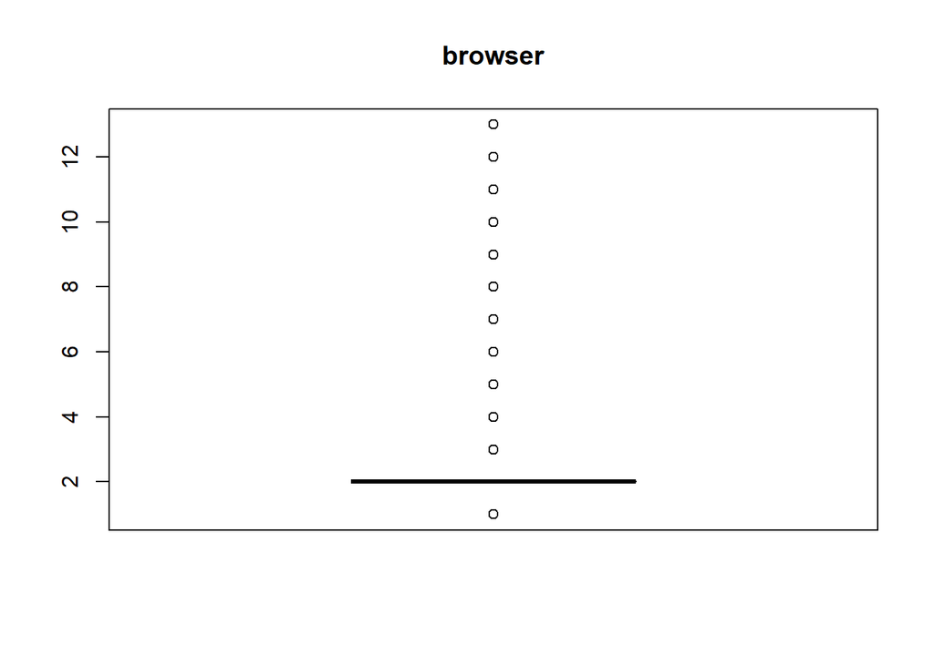

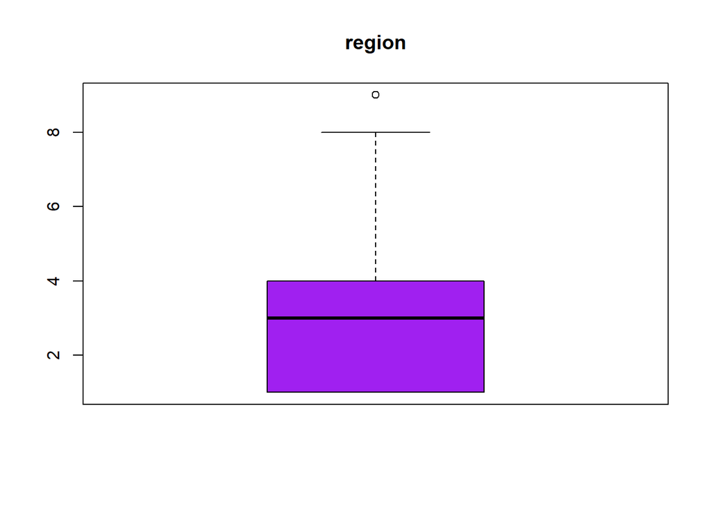

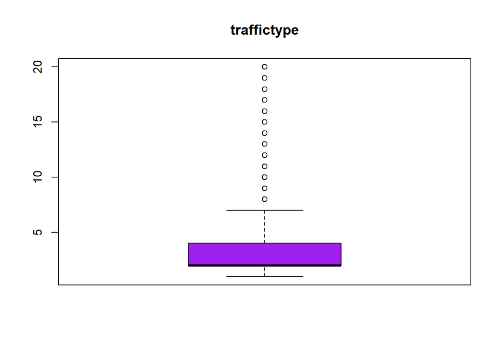

```r
#Outliers in the last columns
for(i in 12:15) {
    boxplot(df[,i], main=names(df)[i], col = "purple")}
```

There are outliers present in the dataset. However, we don’t drop them as they are true values.

```r
#Defining numerical columns
numeric <- df%>%select_if(is.numeric)
```

# 5. Perform Exploratory Data Analysis

We now plot to find more information about the dataset. ## 5.1 Univariate Analysis

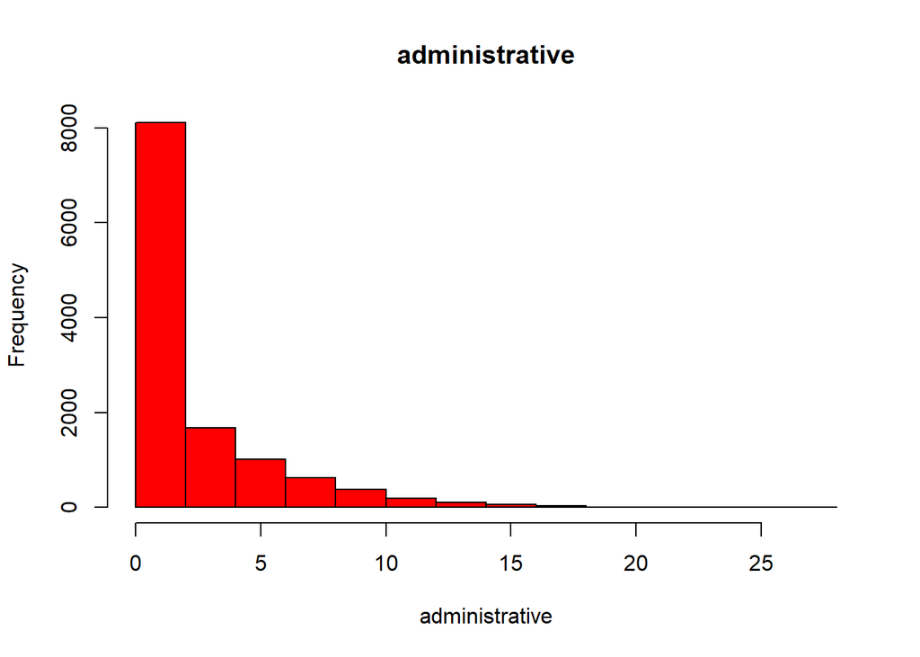

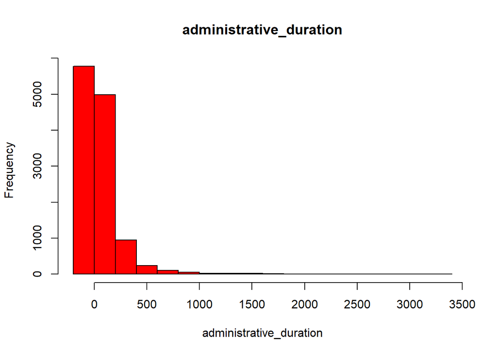

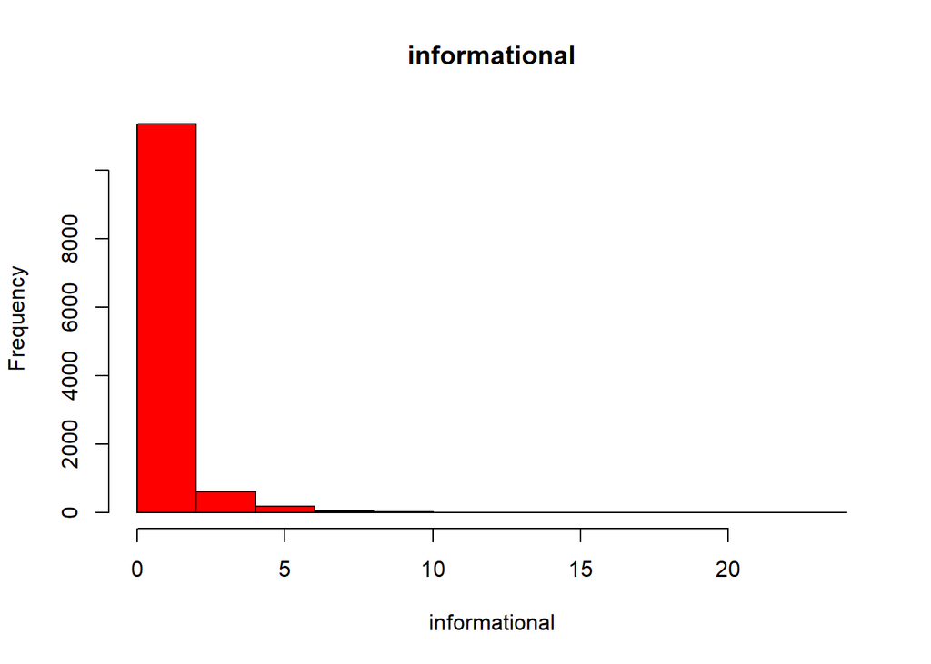

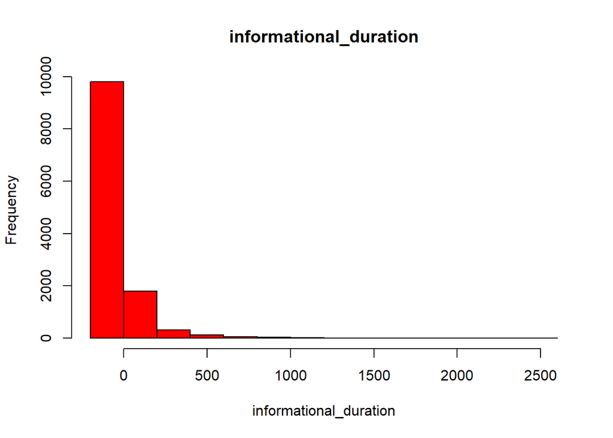

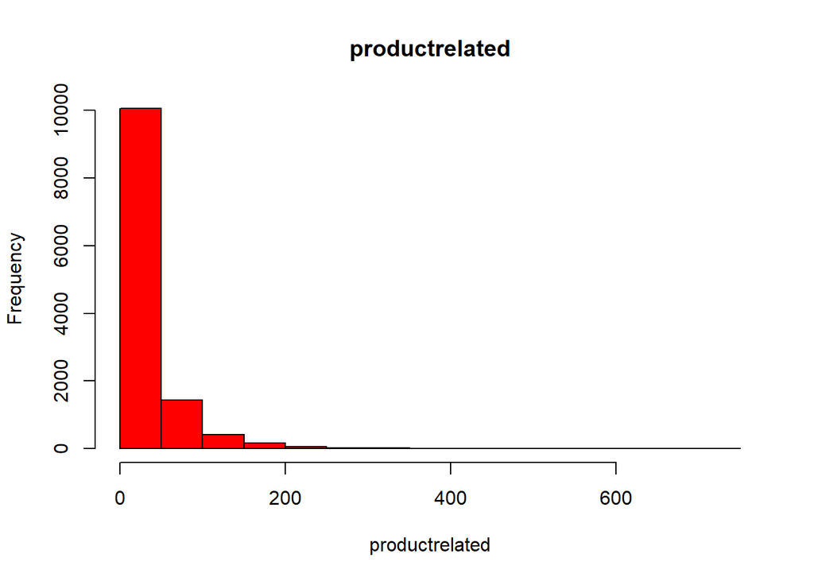

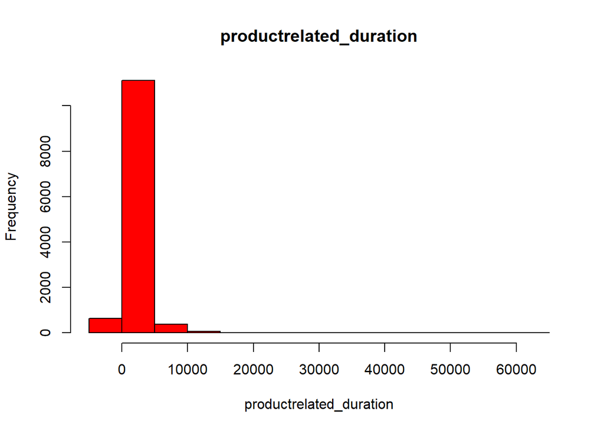

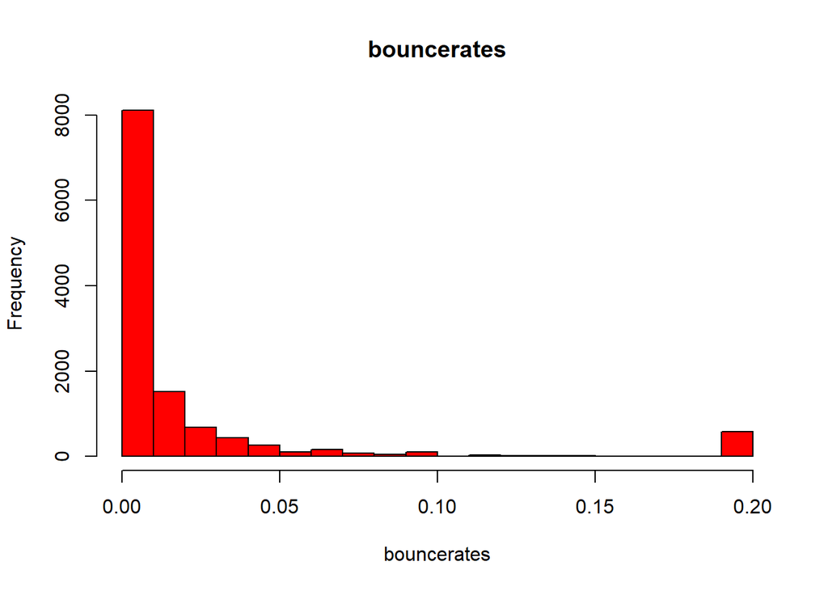

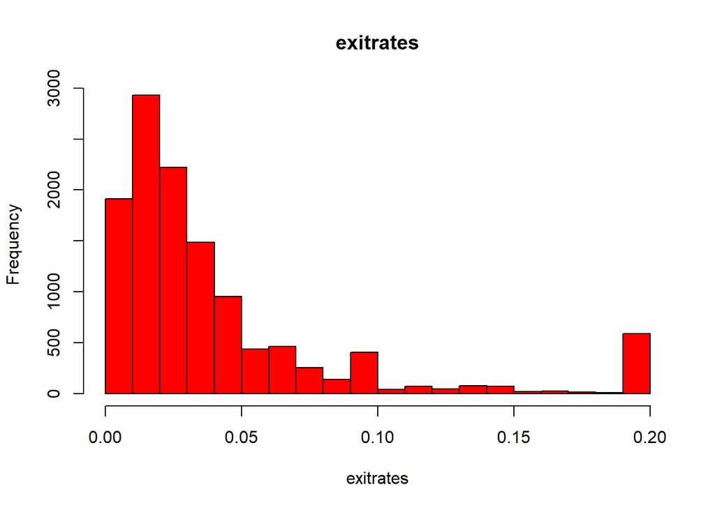

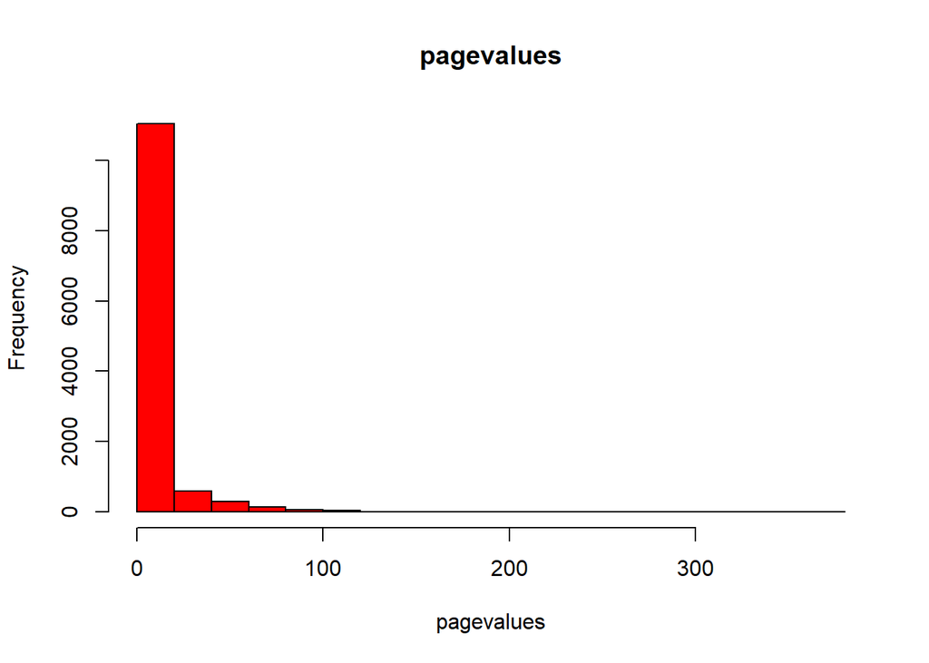

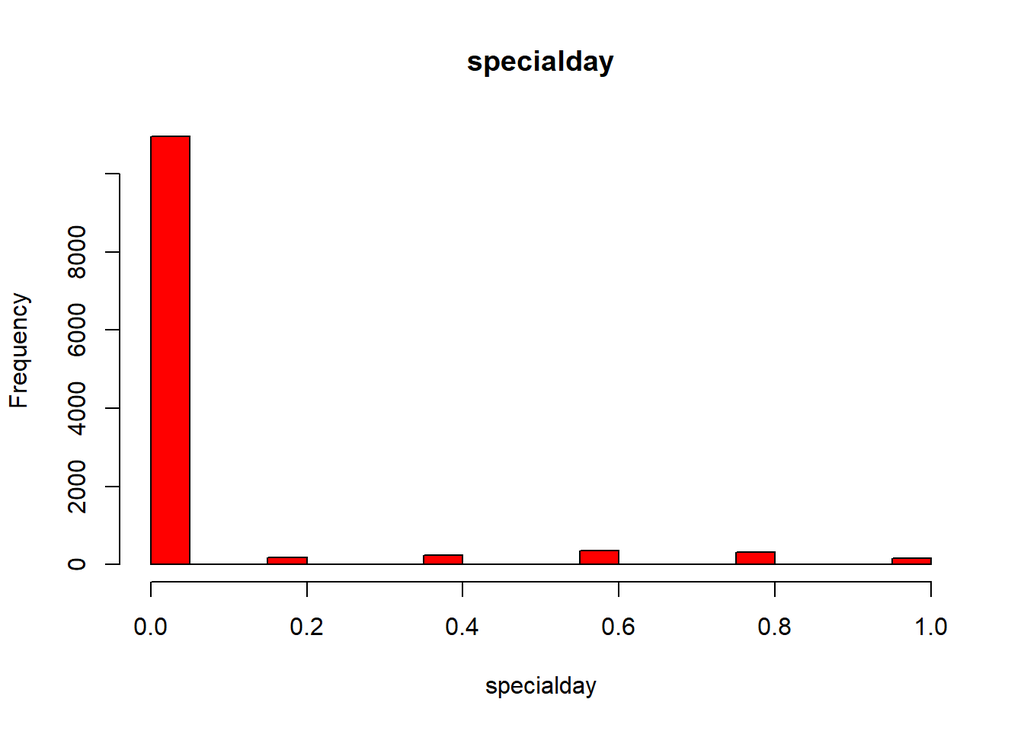

```r
#Plotting histograms
for(i in 1:10) {
    hist(df[,i], main=names(df)[i], xlab=names(df)[i],col = "red")}
```

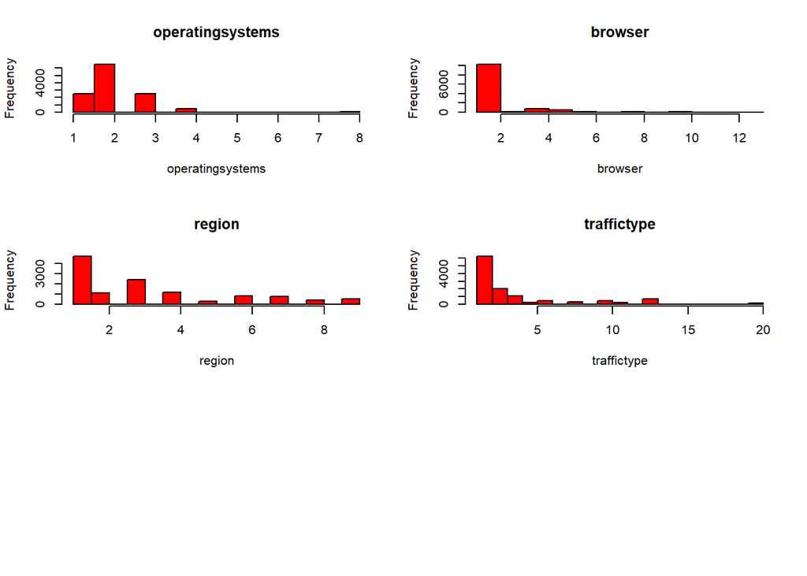

```r
#Plotting histograms
par(mfrow=c(3,2))
for(i in 12:15) {
    hist(df[,i], main=names(df)[i], xlab=names(df)[i],col = "red")}
```

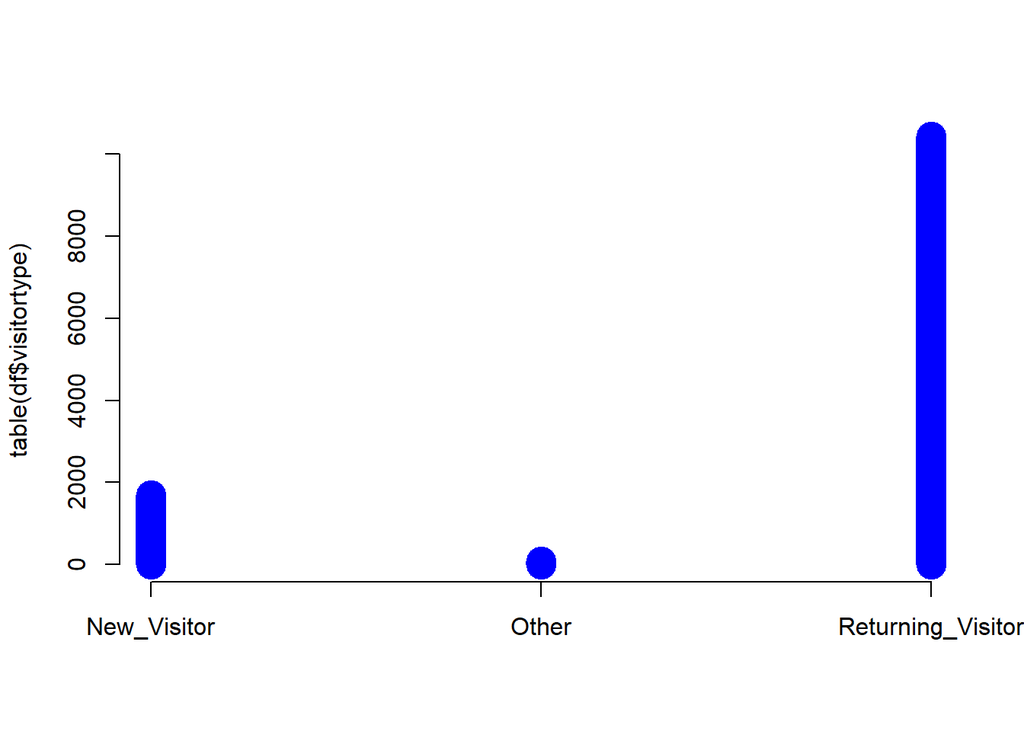

```r
plot(table(df$visitortype),lwd=20, col="blue")
```

Most visitors are returning visitors.

```r
#Getting statistical values of the dataset
library(psych)
describe(numeric)
```

|  | vars | n | mean | sd | median | trimmed | mad | min | max | range | skew | kurtosis | se |
| --- | --- | --- | --- | --- | --- | --- | --- | --- | --- | --- | --- | --- | --- |
| administrative | 1 | 12199 | 2.340028e+00 | 3.330851e+00 | 1.000000e+00 | 1.656593e+00 | 1.482600e+00 | 0 | 27.0000 | 27.0000 | 1.946009 | 4.6348537 | 3.015735e-02 |
| administrative_duration | 2 | 12199 | 8.168214e+01 | 1.775282e+02 | 9.000000e+00 | 4.286683e+01 | 1.334340e+01 | -1 | 3398.7500 | 3399.7500 | 5.589523 | 50.0851812 | 1.607330e+00 |
| informational | 3 | 12199 | 5.088122e-01 | 1.275817e+00 | 0.000000e+00 | 1.824608e-01 | 0.000000e+00 | 0 | 24.0000 | 24.0000 | 4.012958 | 26.6376802 | 1.155118e-02 |
| informational_duration | 4 | 12199 | 3.483734e+01 | 1.414585e+02 | 0.000000e+00 | 3.726866e+00 | 0.000000e+00 | -1 | 2549.3750 | 2550.3750 | 7.536508 | 75.4512246 | 1.280758e+00 |
| productrelated | 5 | 12199 | 3.205845e+01 | 4.460091e+01 | 1.800000e+01 | 2.305573e+01 | 1.927380e+01 | 0 | 705.0000 | 705.0000 | 4.331601 | 31.0434452 | 4.038142e-01 |
| productrelated_duration | 6 | 12199 | 1.207508e+03 | 1.919927e+03 | 6.095417e+02 | 8.323577e+02 | 7.451177e+02 | -1 | 63973.5222 | 63974.5222 | 7.250512 | 136.5679069 | 1.738292e+01 |
| bouncerates | 7 | 12199 | 2.044674e-02 | 4.540250e-02 | 2.930403e-03 | 8.135649e-03 | 4.344615e-03 | 0 | 0.2000 | 0.2000 | 3.152486 | 9.2530550 | 4.110718e-04 |
| exitrates | 8 | 12199 | 4.149678e-02 | 4.624716e-02 | 2.500000e-02 | 3.131007e-02 | 2.059167e-02 | 0 | 0.2000 | 0.2000 | 2.232851 | 4.6230025 | 4.187193e-04 |
| pagevalues | 9 | 12199 | 5.952500e+00 | 1.865779e+01 | 0.000000e+00 | 1.331972e+00 | 0.000000e+00 | 0 | 361.7637 | 361.7637 | 6.347882 | 64.9291691 | 1.689266e-01 |
| specialday | 10 | 12199 | 6.197229e-02 | 1.997106e-01 | 0.000000e+00 | 6.146911e-04 | 0.000000e+00 | 0 | 1.0000 | 1.0000 | 3.284077 | 9.7839577 | 1.808169e-03 |

[output cut: 4 more lines]

We get valuable statistical information on the created data frame. ## 5.2 Bivariate Analysis

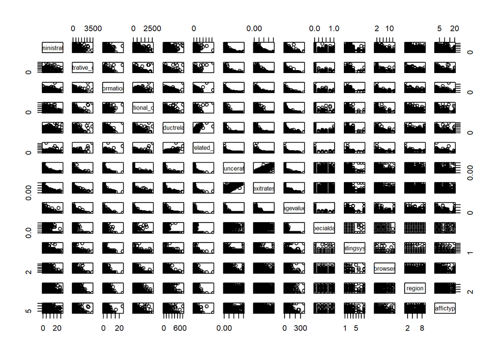

```r
#Pairplot for numeric columns
plot(numeric)
```

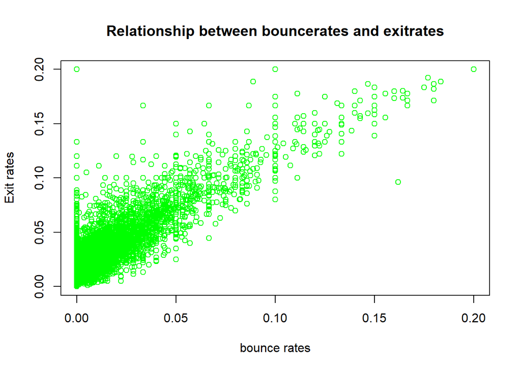

```r
#Plotting bouncerates against exitrates
plot(df$bouncerates, df$exitrates,
     col="green",
     ylab="Exit rates",
     xlab="bounce rates",
     main="Relationship between bouncerates and exitrates")
```

There is a linear relationship between bouncerates and exit rates.

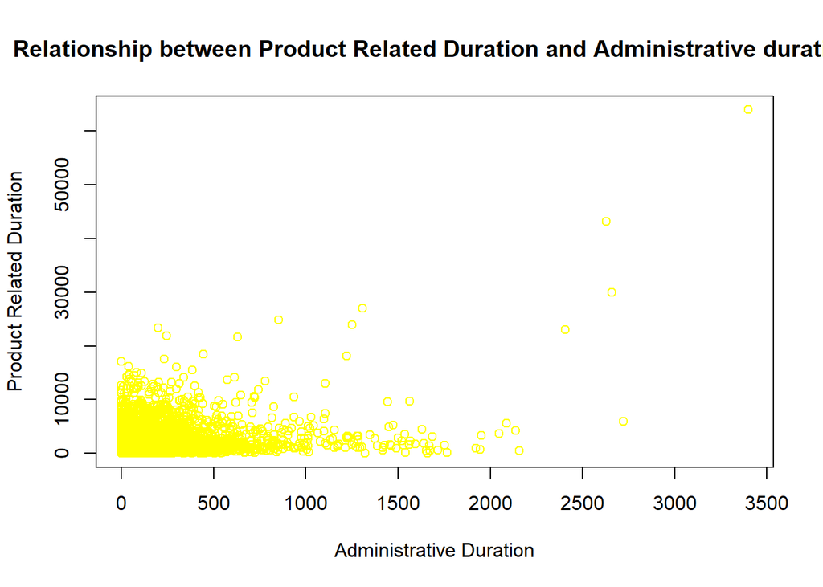

```r
plot(df$administrative_duration, df$productrelated_duration,
     col="yellow",
     ylab="Product Related Duration",
     xlab="Administrative Duration",
     main="Relationship between Product Related Duration and Administrative duration")
```

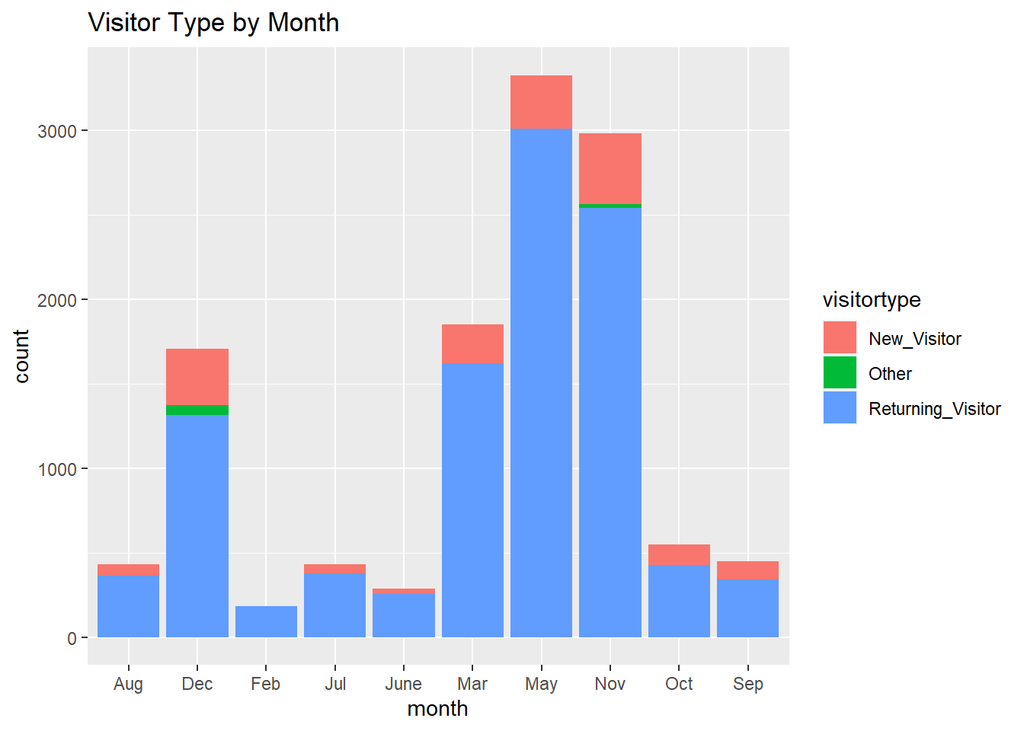

```r
#Stacked Chart of Visitor type by Month
library(ggplot2)
df%>%
  ggplot(aes(month))+
  geom_bar(aes(fill=visitortype))+
  labs(title = "Visitor Type by Month")
```

## 5.3 Multivariate Analysis

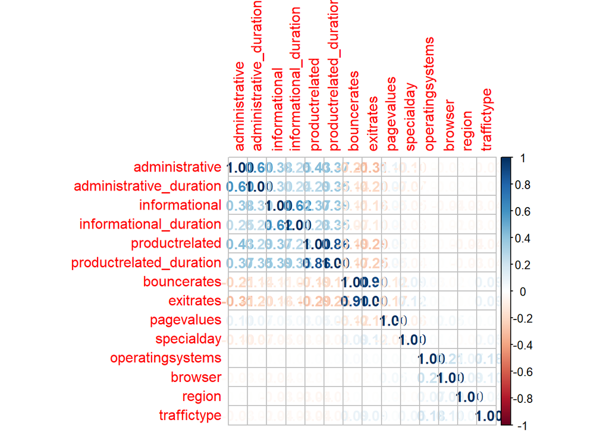

```r
library(corrplot)
# calculate correlations
correlations <- cor(numeric)
# create correlation plot
corrplot(correlations, method="number")
```

```r
#Encoding our dataset
library(superml)
df$weekend <- ifelse(df$weekend == TRUE, 1, 0)
df$revenue <- ifelse(df$revenue == TRUE, 1, 0)
label <- LabelEncoder$new()

#Label encoding the month
df$month <- label$fit_transform(df$month)
df$visitortype <- label$fit_transform(df$visitortype)
```

```r
#Checking if the changes have taken effect
head(df)
```

|  | administrative | administrative_duration | informational | informational_duration | productrelated | productrelated_duration | bouncerates | exitrates | pagevalues | specialday | month | operatingsystems | browser | region | traffictype | visitortype | weekend | revenue |
| --- | --- | --- | --- | --- | --- | --- | --- | --- | --- | --- | --- | --- | --- | --- | --- | --- | --- | --- |
| 1 | 0 | 0 | 0 | 0 | 1 | 0.000000 | 0.20000000 | 0.2000000 | 0 | 0 | 0 | 1 | 1 | 1 | 1 | 0 | 0 | 0 |
| 2 | 0 | 0 | 0 | 0 | 2 | 64.000000 | 0.00000000 | 0.1000000 | 0 | 0 | 0 | 2 | 2 | 1 | 2 | 0 | 0 | 0 |
| 3 | 0 | -1 | 0 | -1 | 1 | -1.000000 | 0.20000000 | 0.2000000 | 0 | 0 | 0 | 4 | 1 | 9 | 3 | 0 | 0 | 0 |
| 4 | 0 | 0 | 0 | 0 | 2 | 2.666667 | 0.05000000 | 0.1400000 | 0 | 0 | 0 | 3 | 2 | 2 | 4 | 0 | 0 | 0 |
| 5 | 0 | 0 | 0 | 0 | 10 | 627.500000 | 0.02000000 | 0.0500000 | 0 | 0 | 0 | 3 | 3 | 1 | 4 | 0 | 1 | 0 |
| 6 | 0 | 0 | 0 | 0 | 19 | 154.216667 | 0.01578947 | 0.0245614 | 0 | 0 | 0 | 2 | 2 | 1 | 3 | 0 | 0 | 0 |

Now the dataset can be modeled.